# Project2

Rinku Lichti, Simerpreet Reddy, Megan Ball

11/4/2020

# Load Data

```r
#full <- read_delim(here::here("data", "bank-additional-full.csv"),';')
full <- read.csv(file.choose(), sep=';')
str(full)
```

```
## 'data.frame':    41188 obs. of  21 variables:
##  $ age           : int  56 57 37 40 56 45 59 41 24 25 ...
##  $ job           : chr  "housemaid" "services" "services" "admin." ...
##  $ marital       : chr  "married" "married" "married" "married" ...
##  $ education     : chr  "basic.4y" "high.school" "high.school" "basic.6y" ...
##  $ default       : chr  "no" "unknown" "no" "no" ...
##  $ housing       : chr  "no" "no" "yes" "no" ...
##  $ loan          : chr  "no" "no" "no" "no" ...
##  $ contact       : chr  "telephone" "telephone" "telephone" "telephone" ...
##  $ month         : chr  "may" "may" "may" "may" ...
##  $ day_of_week   : chr  "mon" "mon" "mon" "mon" ...
##  $ duration      : int  261 149 226 151 307 198 139 217 380 50 ...
##  $ campaign      : int  1 1 1 1 1 1 1 1 1 1 ...
##  $ pdays         : int  999 999 999 999 999 999 999 999 999 999 ...
##  $ previous      : int  0 0 0 0 0 0 0 0 0 0 ...
##  $ poutcome      : chr  "nonexistent" "nonexistent" "nonexistent" "nonexistent" ...
##  $ emp.var.rate  : num  1.1 1.1 1.1 1.1 1.1 1.1 1.1 1.1 1.1 1.1 ...
##  $ cons.price.idx: num  94 94 94 94 94 ...
##  $ cons.conf.idx : num  -36.4 -36.4 -36.4 -36.4 -36.4 -36.4 -36.4 -36.4 -36.4 -36.4 ...
##  $ euribor3m     : num  4.86 4.86 4.86 4.86 4.86 ...
##  $ nr.employed   : num  5191 5191 5191 5191 5191 ...
##  $ y             : chr  "no" "no" "no" "no" ...
```

```r
head(full)
```

```
##   age       job marital   education default housing loan   contact month
## 1  56 housemaid married    basic.4y      no      no   no telephone   may
## 2  57  services married high.school unknown      no   no telephone   may
## 3  37  services married high.school      no     yes   no telephone   may
## 4  40    admin. married    basic.6y      no      no   no telephone   may
## 5  56  services married high.school      no      no  yes telephone   may
## 6  45  services married    basic.9y unknown      no   no telephone   may
##   day_of_week duration campaign pdays previous    poutcome emp.var.rate
## 1         mon      261        1   999        0 nonexistent          1.1
## 2         mon      149        1   999        0 nonexistent          1.1
## 3         mon      226        1   999        0 nonexistent          1.1
## 4         mon      151        1   999        0 nonexistent          1.1
## 5         mon      307        1   999        0 nonexistent          1.1
## 6         mon      198        1   999        0 nonexistent          1.1
##   cons.price.idx cons.conf.idx euribor3m nr.employed  y
## 1         93.994         -36.4     4.857        5191 no
## 2         93.994         -36.4     4.857        5191 no
## 3         93.994         -36.4     4.857        5191 no
## 4         93.994         -36.4     4.857        5191 no
## 5         93.994         -36.4     4.857        5191 no
## 6         93.994         -36.4     4.857        5191 no
```

```r
nrow(full)
```

```
## [1] 41188
```

```r
ncol(full)
```

```
## [1] 21
```

```r
# Clean up column names
full <- janitor::clean_names(full)
summary(full)
```

```
##       age            job              marital           education
##  Min.   :17.00   Length:41188       Length:41188       Length:41188
##  1st Qu.:32.00   Class :character   Class :character   Class :character
##  Median :38.00   Mode  :character   Mode  :character   Mode  :character
##  Mean   :40.02
##  3rd Qu.:47.00
##  Max.   :98.00
##    default            housing              loan             contact
##  Length:41188       Length:41188       Length:41188       Length:41188
##  Class :character   Class :character   Class :character   Class :character
##  Mode  :character   Mode  :character   Mode  :character   Mode  :character
##
##
##
##     month           day_of_week           duration         campaign
##  Length:41188       Length:41188       Min.   :   0.0   Min.   : 1.000
##  Class :character   Class :character   1st Qu.: 102.0   1st Qu.: 1.000
##  Mode  :character   Mode  :character   Median : 180.0   Median : 2.000
##                                        Mean   : 258.3   Mean   : 2.568
##                                        3rd Qu.: 319.0   3rd Qu.: 3.000
##                                        Max.   :4918.0   Max.   :56.000
##      pdays          previous       poutcome          emp_var_rate
##  Min.   :  0.0   Min.   :0.000   Length:41188       Min.   :-3.40000
##  1st Qu.:999.0   1st Qu.:0.000   Class :character   1st Qu.:-1.80000
##  Median :999.0   Median :0.000   Mode  :character   Median : 1.10000
##  Mean   :962.5   Mean   :0.173                      Mean   : 0.08189
##  3rd Qu.:999.0   3rd Qu.:0.000                      3rd Qu.: 1.40000
##  Max.   :999.0   Max.   :7.000                      Max.   : 1.40000
##  cons_price_idx  cons_conf_idx     euribor3m      nr_employed
##  Min.   :92.20   Min.   :-50.8   Min.   :0.634   Min.   :4964
##  1st Qu.:93.08   1st Qu.:-42.7   1st Qu.:1.344   1st Qu.:5099
##  Median :93.75   Median :-41.8   Median :4.857   Median :5191
##  Mean   :93.58   Mean   :-40.5   Mean   :3.621   Mean   :5167
##  3rd Qu.:93.99   3rd Qu.:-36.4   3rd Qu.:4.961   3rd Qu.:5228
##  Max.   :94.77   Max.   :-26.9   Max.   :5.045   Max.   :5228
##       y
##  Length:41188
##  Class :character
##  Mode  :character
##
##
##
```

```r
#print(dfSummary(full, graph.magnif = 0.75), method = 'browser')
str(full)
```

```
## 'data.frame':    41188 obs. of  21 variables:
##  $ age           : int  56 57 37 40 56 45 59 41 24 25 ...
##  $ job           : chr  "housemaid" "services" "services" "admin." ...
##  $ marital       : chr  "married" "married" "married" "married" ...
##  $ education     : chr  "basic.4y" "high.school" "high.school" "basic.6y" ...
##  $ default       : chr  "no" "unknown" "no" "no" ...
##  $ housing       : chr  "no" "no" "yes" "no" ...
##  $ loan          : chr  "no" "no" "no" "no" ...
##  $ contact       : chr  "telephone" "telephone" "telephone" "telephone" ...
##  $ month         : chr  "may" "may" "may" "may" ...
##  $ day_of_week   : chr  "mon" "mon" "mon" "mon" ...
##  $ duration      : int  261 149 226 151 307 198 139 217 380 50 ...
##  $ campaign      : int  1 1 1 1 1 1 1 1 1 1 ...
##  $ pdays         : int  999 999 999 999 999 999 999 999 999 999 ...
##  $ previous      : int  0 0 0 0 0 0 0 0 0 0 ...
##  $ poutcome      : chr  "nonexistent" "nonexistent" "nonexistent" "nonexistent" ...
##  $ emp_var_rate  : num  1.1 1.1 1.1 1.1 1.1 1.1 1.1 1.1 1.1 1.1 ...
##  $ cons_price_idx: num  94 94 94 94 94 ...
##  $ cons_conf_idx : num  -36.4 -36.4 -36.4 -36.4 -36.4 -36.4 -36.4 -36.4 -36.4 -36.4 ...
##  $ euribor3m     : num  4.86 4.86 4.86 4.86 4.86 ...
##  $ nr_employed   : num  5191 5191 5191 5191 5191 ...
##  $ y             : chr  "no" "no" "no" "no" ...
```

```r
# Check for missing values
tibble(variable = names(colSums(is.na(full))),
       missing = colSums(is.na(full))) %>%
  gt() %>%
  tab_header(title = "Missing Values in Data")
```

Missing Values in Data

| variable | missing |
| --- | --- |
| age | 0 |
| job | 0 |
| marital | 0 |
| education | 0 |
| default | 0 |
| housing | 0 |
| loan | 0 |
| contact | 0 |
| month | 0 |
| day_of_week | 0 |
| duration | 0 |
| campaign | 0 |
| pdays | 0 |
| previous | 0 |
| poutcome | 0 |
| emp_var_rate | 0 |
| cons_price_idx | 0 |
| cons_conf_idx | 0 |
| euribor3m | 0 |
| nr_employed | 0 |
| y | 0 |

pdays: number of days that passed by after the client was last contacted from a previous campaign (numeric; 999 means client was not previously contacted)

# Remove missing values

```r
#remove "unknowns" based on small sample sizes compared to full data set
df <- full %>%  filter(loan != "unknown")
nrow(df)
```

```
## [1] 40198
```

```r
#down to 40,198 obs
df <- df %>%  filter(marital != "unknown")
nrow(df)
```

```
## [1] 40119
```

```r
#down to 40,119 obs
df <- df %>%  filter(education != "unknown")
nrow(df)
```

```
## [1] 38437
```

```r
#down to 38,437 obs
#remove unknowns from job
df <- df %>%  filter(job != "unknown")
nrow(df)
```

```
## [1] 38245
```

```r
#down to 38,245 obs
#remove yes from default - only 3, and all 3 are "no"
df <- df %>%  filter(default != "yes")
nrow(df)
```

```
## [1] 38242
```

```r
#down to 38,242 obs
str(df)
```

```
## 'data.frame':    38242 obs. of  21 variables:
##  $ age           : int  56 57 37 40 56 45 59 24 25 25 ...
##  $ job           : chr  "housemaid" "services" "services" "admin." ...
##  $ marital       : chr  "married" "married" "married" "married" ...
##  $ education     : chr  "basic.4y" "high.school" "high.school" "basic.6y" ...
##  $ default       : chr  "no" "unknown" "no" "no" ...
##  $ housing       : chr  "no" "no" "yes" "no" ...
##  $ loan          : chr  "no" "no" "no" "no" ...
##  $ contact       : chr  "telephone" "telephone" "telephone" "telephone" ...
##  $ month         : chr  "may" "may" "may" "may" ...
##  $ day_of_week   : chr  "mon" "mon" "mon" "mon" ...
##  $ duration      : int  261 149 226 151 307 198 139 380 50 222 ...
##  $ campaign      : int  1 1 1 1 1 1 1 1 1 1 ...
##  $ pdays         : int  999 999 999 999 999 999 999 999 999 999 ...
##  $ previous      : int  0 0 0 0 0 0 0 0 0 0 ...
##  $ poutcome      : chr  "nonexistent" "nonexistent" "nonexistent" "nonexistent" ...
##  $ emp_var_rate  : num  1.1 1.1 1.1 1.1 1.1 1.1 1.1 1.1 1.1 1.1 ...
##  $ cons_price_idx: num  94 94 94 94 94 ...
##  $ cons_conf_idx : num  -36.4 -36.4 -36.4 -36.4 -36.4 -36.4 -36.4 -36.4 -36.4 -36.4 ...
##  $ euribor3m     : num  4.86 4.86 4.86 4.86 4.86 ...
##  $ nr_employed   : num  5191 5191 5191 5191 5191 ...
##  $ y             : chr  "no" "no" "no" "no" ...
```

```r
#recheck summary
summary(df)
```

```
##       age            job              marital           education
##  Min.   :17.00   Length:38242       Length:38242       Length:38242
##  1st Qu.:32.00   Class :character   Class :character   Class :character
##  Median :38.00   Mode  :character   Mode  :character   Mode  :character
##  Mean   :39.86
##  3rd Qu.:47.00
##  Max.   :98.00
##    default            housing              loan             contact
##  Length:38242       Length:38242       Length:38242       Length:38242
##  Class :character   Class :character   Class :character   Class :character
##  Mode  :character   Mode  :character   Mode  :character   Mode  :character
##
##
##
##     month           day_of_week           duration         campaign
##  Length:38242       Length:38242       Min.   :   0.0   Min.   : 1.000
##  Class :character   Class :character   1st Qu.: 102.0   1st Qu.: 1.000
##  Mode  :character   Mode  :character   Median : 180.0   Median : 2.000
##                                        Mean   : 258.2   Mean   : 2.567
##                                        3rd Qu.: 319.0   3rd Qu.: 3.000
##                                        Max.   :4918.0   Max.   :43.000
##      pdays          previous      poutcome          emp_var_rate
##  Min.   :  0.0   Min.   :0.00   Length:38242       Min.   :-3.4000
##  1st Qu.:999.0   1st Qu.:0.00   Class :character   1st Qu.:-1.8000
##  Median :999.0   Median :0.00   Mode  :character   Median : 1.1000
##  Mean   :963.5   Mean   :0.17                      Mean   : 0.0828
##  3rd Qu.:999.0   3rd Qu.:0.00                      3rd Qu.: 1.4000
##  Max.   :999.0   Max.   :7.00                      Max.   : 1.4000
##  cons_price_idx  cons_conf_idx      euribor3m      nr_employed
##  Min.   :92.20   Min.   :-50.80   Min.   :0.634   Min.   :4964
##  1st Qu.:93.08   1st Qu.:-42.70   1st Qu.:1.344   1st Qu.:5099
##  Median :93.44   Median :-41.80   Median :4.857   Median :5191
##  Mean   :93.57   Mean   :-40.54   Mean   :3.623   Mean   :5167
##  3rd Qu.:93.99   3rd Qu.:-36.40   3rd Qu.:4.961   3rd Qu.:5228
##  Max.   :94.77   Max.   :-26.90   Max.   :5.045   Max.   :5228
##       y
##  Length:38242
##  Class :character
##  Mode  :character
##
##
##
```

```r
summary(df)
```

```
##       age            job              marital           education
##  Min.   :17.00   Length:38242       Length:38242       Length:38242
##  1st Qu.:32.00   Class :character   Class :character   Class :character
##  Median :38.00   Mode  :character   Mode  :character   Mode  :character
##  Mean   :39.86
##  3rd Qu.:47.00
##  Max.   :98.00
##    default            housing              loan             contact
##  Length:38242       Length:38242       Length:38242       Length:38242
##  Class :character   Class :character   Class :character   Class :character
##  Mode  :character   Mode  :character   Mode  :character   Mode  :character
##
##
##
##     month           day_of_week           duration         campaign
##  Length:38242       Length:38242       Min.   :   0.0   Min.   : 1.000
##  Class :character   Class :character   1st Qu.: 102.0   1st Qu.: 1.000
##  Mode  :character   Mode  :character   Median : 180.0   Median : 2.000
##                                        Mean   : 258.2   Mean   : 2.567
##                                        3rd Qu.: 319.0   3rd Qu.: 3.000
##                                        Max.   :4918.0   Max.   :43.000
##      pdays          previous      poutcome          emp_var_rate
##  Min.   :  0.0   Min.   :0.00   Length:38242       Min.   :-3.4000
##  1st Qu.:999.0   1st Qu.:0.00   Class :character   1st Qu.:-1.8000
##  Median :999.0   Median :0.00   Mode  :character   Median : 1.1000
##  Mean   :963.5   Mean   :0.17                      Mean   : 0.0828
##  3rd Qu.:999.0   3rd Qu.:0.00                      3rd Qu.: 1.4000
##  Max.   :999.0   Max.   :7.00                      Max.   : 1.4000
##  cons_price_idx  cons_conf_idx      euribor3m      nr_employed
##  Min.   :92.20   Min.   :-50.80   Min.   :0.634   Min.   :4964
##  1st Qu.:93.08   1st Qu.:-42.70   1st Qu.:1.344   1st Qu.:5099
##  Median :93.44   Median :-41.80   Median :4.857   Median :5191
##  Mean   :93.57   Mean   :-40.54   Mean   :3.623   Mean   :5167
##  3rd Qu.:93.99   3rd Qu.:-36.40   3rd Qu.:4.961   3rd Qu.:5228
##  Max.   :94.77   Max.   :-26.90   Max.   :5.045   Max.   :5228
##       y
##  Length:38242
##  Class :character
##  Mode  :character
##
##
##
```

Our yes group has decreased by about ~400 to 4,258.

```r
#change some variables to factor
cols <- c("job", "marital", "education", "housing","loan","contact","month","day_of_week","default","poutcome","y")
df[cols] <- lapply(df[cols], factor)
str(df)
```

```
## 'data.frame':    38242 obs. of  21 variables:
##  $ age           : int  56 57 37 40 56 45 59 24 25 25 ...
##  $ job           : Factor w/ 11 levels "admin.","blue-collar",..: 4 8 8 1 8 8 1 10 8 8 ...
##  $ marital       : Factor w/ 3 levels "divorced","married",..: 2 2 2 2 2 2 2 3 3 3 ...
##  $ education     : Factor w/ 7 levels "basic.4y","basic.6y",..: 1 4 4 2 4 3 6 6 4 4 ...
##  $ default       : Factor w/ 2 levels "no","unknown": 1 2 1 1 1 2 1 1 1 1 ...
##  $ housing       : Factor w/ 2 levels "no","yes": 1 1 2 1 1 1 1 2 2 2 ...
##  $ loan          : Factor w/ 2 levels "no","yes": 1 1 1 1 2 1 1 1 1 1 ...
##  $ contact       : Factor w/ 2 levels "cellular","telephone": 2 2 2 2 2 2 2 2 2 2 ...
##  $ month         : Factor w/ 10 levels "apr","aug","dec",..: 7 7 7 7 7 7 7 7 7 7 ...
##  $ day_of_week   : Factor w/ 5 levels "fri","mon","thu",..: 2 2 2 2 2 2 2 2 2 2 ...
##  $ duration      : int  261 149 226 151 307 198 139 380 50 222 ...
##  $ campaign      : int  1 1 1 1 1 1 1 1 1 1 ...
##  $ pdays         : int  999 999 999 999 999 999 999 999 999 999 ...
##  $ previous      : int  0 0 0 0 0 0 0 0 0 0 ...
##  $ poutcome      : Factor w/ 3 levels "failure","nonexistent",..: 2 2 2 2 2 2 2 2 2 2 ...
##  $ emp_var_rate  : num  1.1 1.1 1.1 1.1 1.1 1.1 1.1 1.1 1.1 1.1 ...
##  $ cons_price_idx: num  94 94 94 94 94 ...
##  $ cons_conf_idx : num  -36.4 -36.4 -36.4 -36.4 -36.4 -36.4 -36.4 -36.4 -36.4 -36.4 ...
##  $ euribor3m     : num  4.86 4.86 4.86 4.86 4.86 ...
##  $ nr_employed   : num  5191 5191 5191 5191 5191 ...
##  $ y             : Factor w/ 2 levels "no","yes": 1 1 1 1 1 1 1 1 1 1 ...
```

```r
#make sure "success" level is defined as "yes"
str(df$y)
```

```
##  Factor w/ 2 levels "no","yes": 1 1 1 1 1 1 1 1 1 1 ...
```

# Exploratory Data Analysis

```r
#run first pass PCA to see if we have useful numeric predictors
df.numeric <- df[ , sapply(df, is.numeric)]
pc.result<-prcomp(df.numeric,scale.=TRUE)
pc.scores<-pc.result$x
pc.scores<-data.frame(pc.scores)
pc.scores$y<-df$y

#pc.scores

#Scree plot
eigenvals<-(pc.result$sdev)^2
eigenvals
```

```
##  [1] 3.89761881 1.35967518 1.06973450 1.04945508 0.93221207 0.83728417
##  [7] 0.42764325 0.39087410 0.02482374 0.01067909
```

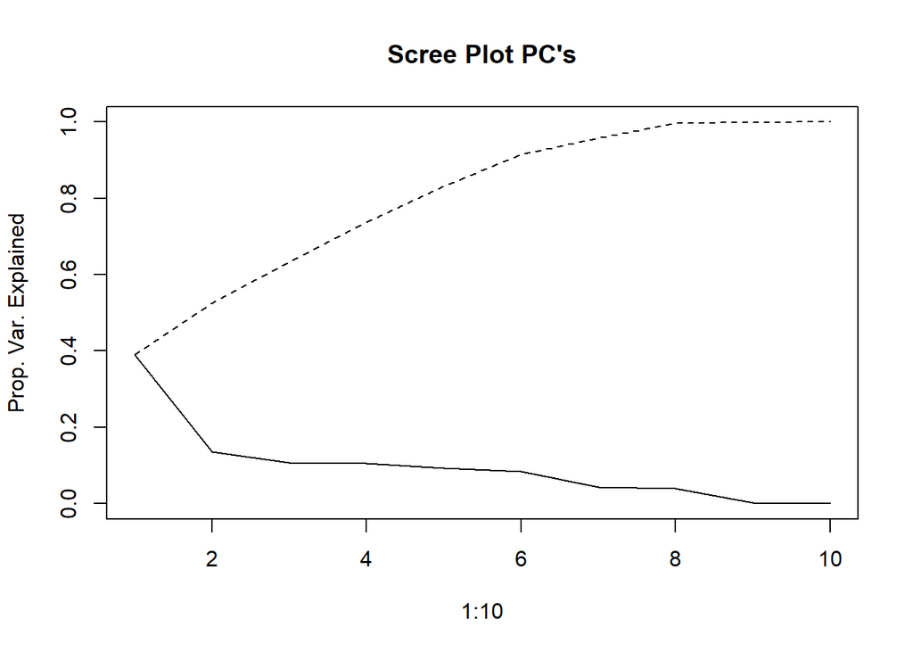

```r
plot(1:10,eigenvals/sum(eigenvals),type="l",main="Scree Plot PC's",ylab="Prop. Var. Explained",ylim=c(0,1))
cumulative.prop<-cumsum(eigenvals/sum(eigenvals))
lines(1:10,cumulative.prop,lty=2)
```

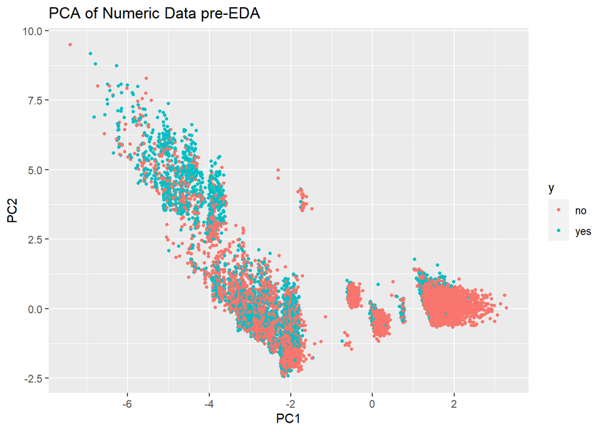

```r
#Use ggplot2 to plot the first few pc's
ggplot(data = pc.scores, aes(x = PC1, y = PC2)) +
  geom_point(aes(col=y), size=1)+
  ggtitle("PCA of Numeric Data pre-EDA")
```

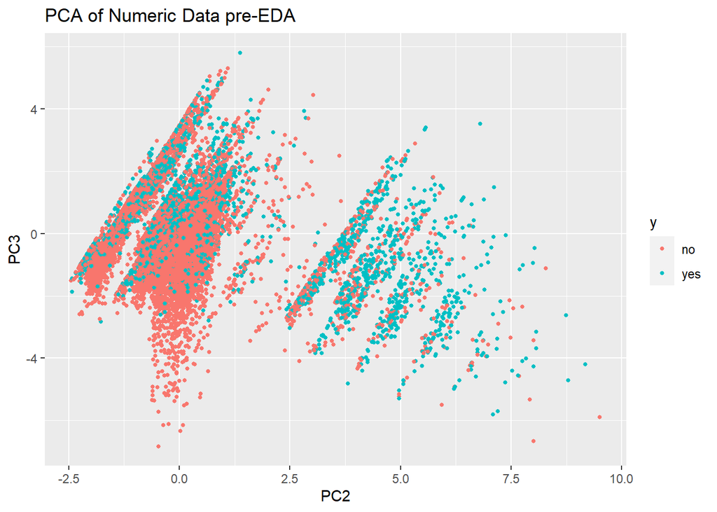

```r
#There is some separation, but it is not in a way we would hope for our response variable
ggplot(data = pc.scores, aes(x = PC2, y = PC3)) +
  geom_point(aes(col=y), size=1)+
  ggtitle("PCA of Numeric Data pre-EDA")
```

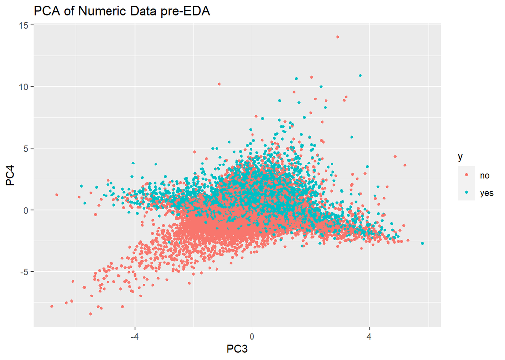

```r
ggplot(data = pc.scores, aes(x = PC3, y = PC4)) +
  geom_point(aes(col=y), size=1)+
  ggtitle("PCA of Numeric Data pre-EDA")
```

PCA without pdays. campaign, and previous as they are more like factors and not continuous

```r
df.numeric2 <- df.numeric %>% dplyr::select(-c(pdays, campaign, previous))
pc.result2<-prcomp(df.numeric2,scale.=TRUE)
pc.scores2<-pc.result2$x
pc.scores2<-data.frame(pc.scores2)
pc.scores2$y<-df$y
#pc.scores2

#Scree plot
eigenvals2<-(pc.result2$sdev)^2
eigenvals2
```

```
## [1] 3.48209924 1.11577551 1.00157280 0.86043468 0.50429117 0.02505300 0.01077359
```

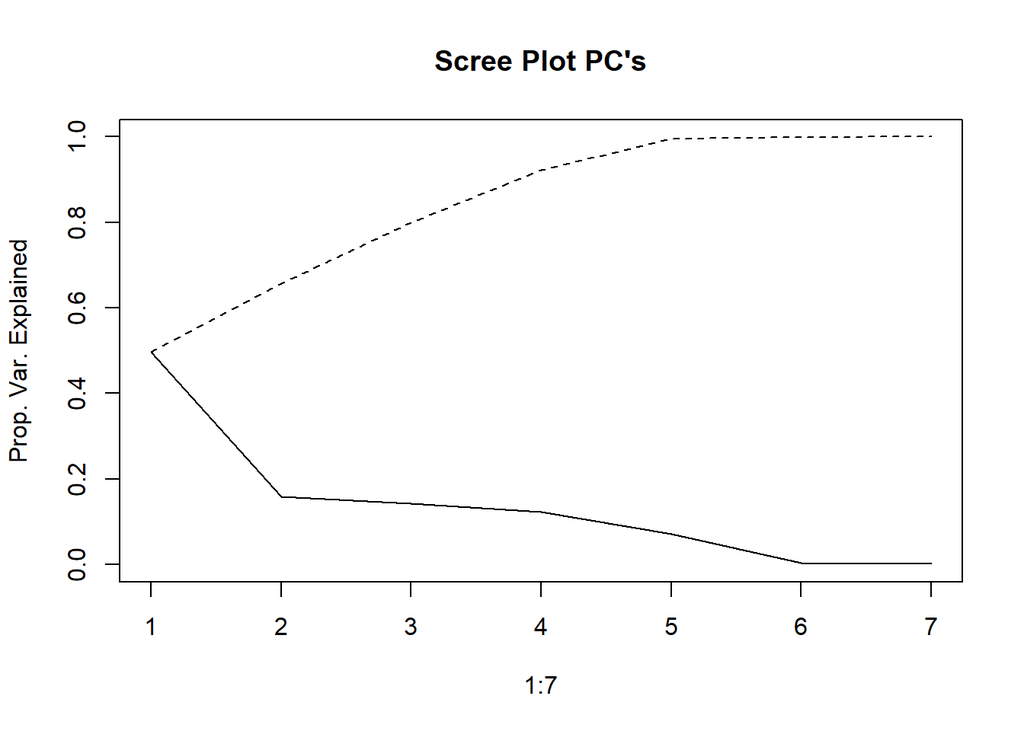

```r
plot(1:7,eigenvals2/sum(eigenvals2),type="l",main="Scree Plot PC's",ylab="Prop. Var. Explained",ylim=c(0,1))
cumulative.prop2<-cumsum(eigenvals2/sum(eigenvals2))
lines(1:7,cumulative.prop2,lty=2)
```

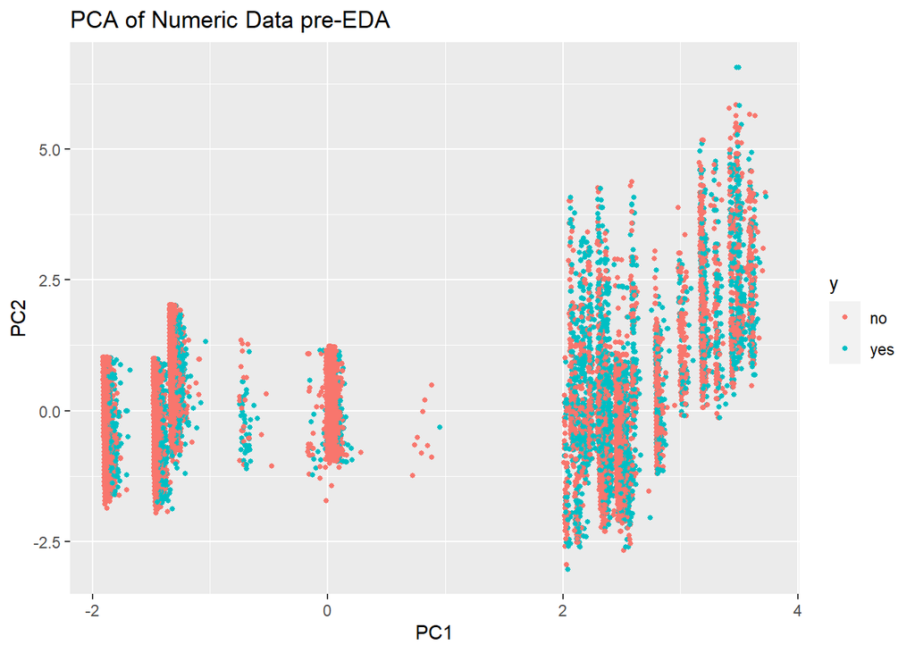

```r
#Use ggplot2 to plot the first few pc's
ggplot(data = pc.scores2, aes(x = PC1, y = PC2)) +
  geom_point(aes(col=y), size=1)+
  ggtitle("PCA of Numeric Data pre-EDA")
```

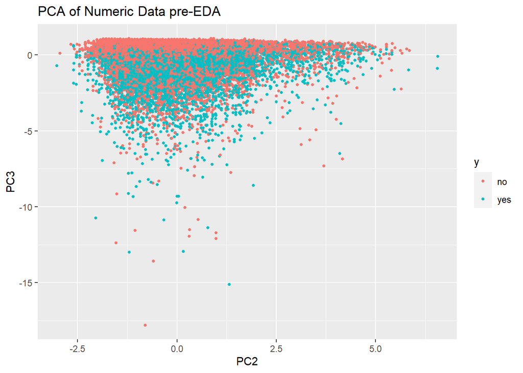

```r
#There is some separation, but it is not in a way we would hope for our response variable
ggplot(data = pc.scores2, aes(x = PC2, y = PC3)) +
  geom_point(aes(col=y), size=1)+
  ggtitle("PCA of Numeric Data pre-EDA")
```

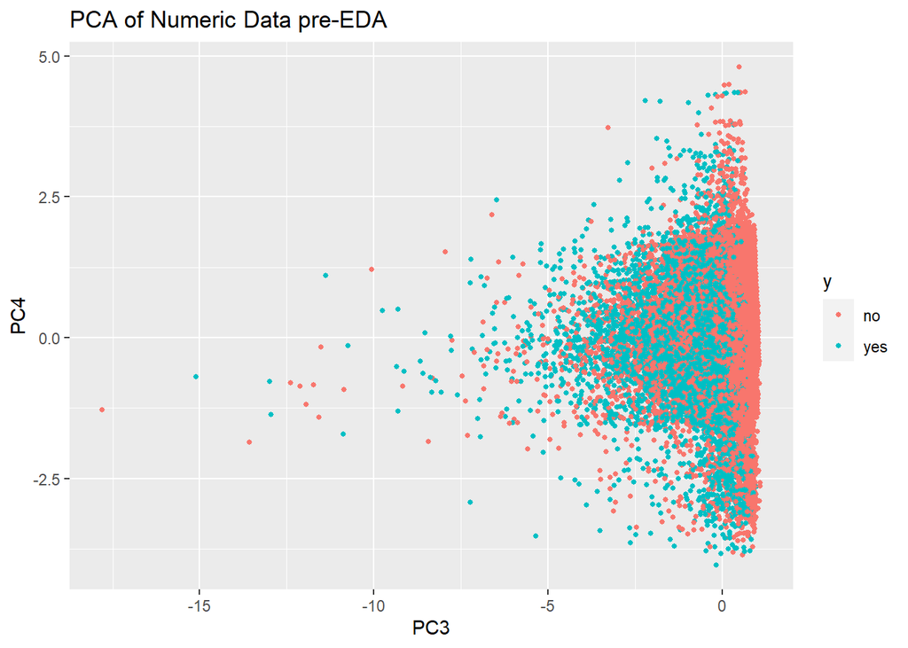

```r
ggplot(data = pc.scores2, aes(x = PC3, y = PC4)) +
  geom_point(aes(col=y), size=1)+
  ggtitle("PCA of Numeric Data pre-EDA")
```

Still does not seem of much value.

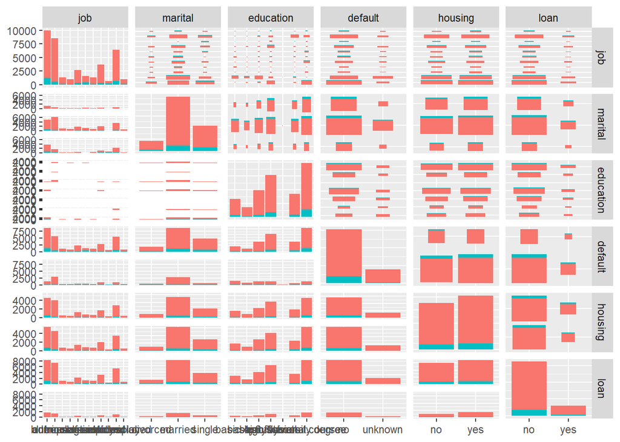

```r
#ggpairs(df,columns=1:18, aes(colour=y))
ggpairs(df,columns=2:7, aes(colour=y))
```

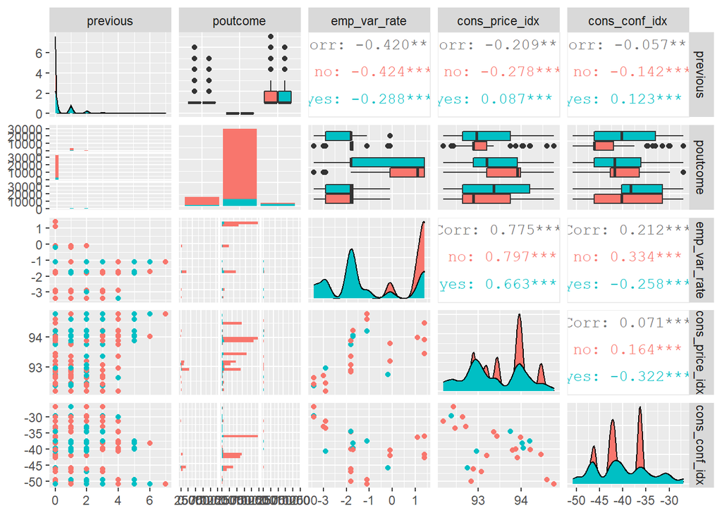

```r
ggpairs(df, columns=14:18, aes(colour=y))
```

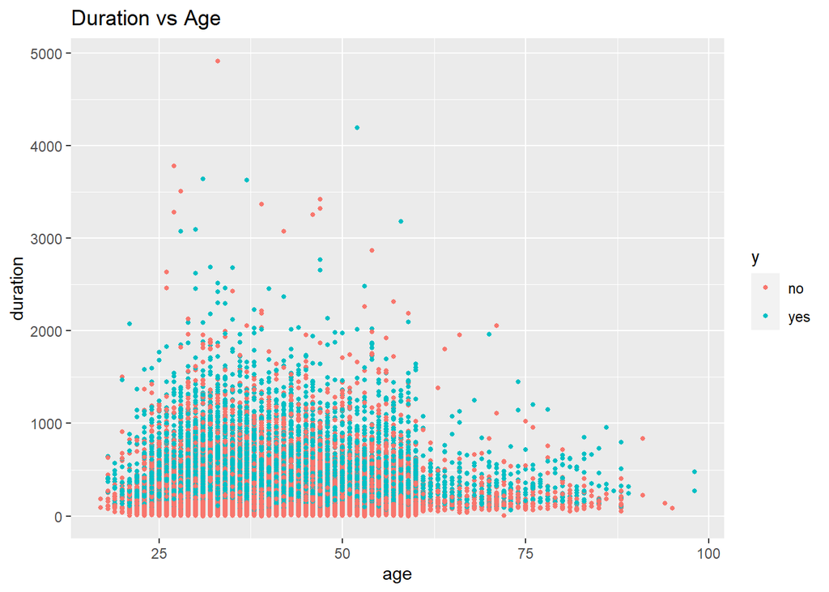

```r
df_yes <- df %>%   filter(y=="yes")

#summary(df_yes)
# Nothing interesting found in the below code so commenting it out
# ggplot(bank_additional_full, aes(x=age, y=emp.var.rate)) +
#   geom_point(size=1, shape="circle") +
#   ggtitle("Employment Variation Rate vs Age") +
#   facet_wrap(~ y)

ggplot(df, aes(x=age, y=duration, color = y)) +  geom_point(size=1, shape="circle") +   ggtitle("Duration vs Age")
```

Duration vs Age: The duration of last contact (in seconds) was longer for ages 25-50. And it was understandably longer for ‘yes’’ vs for ‘no’.

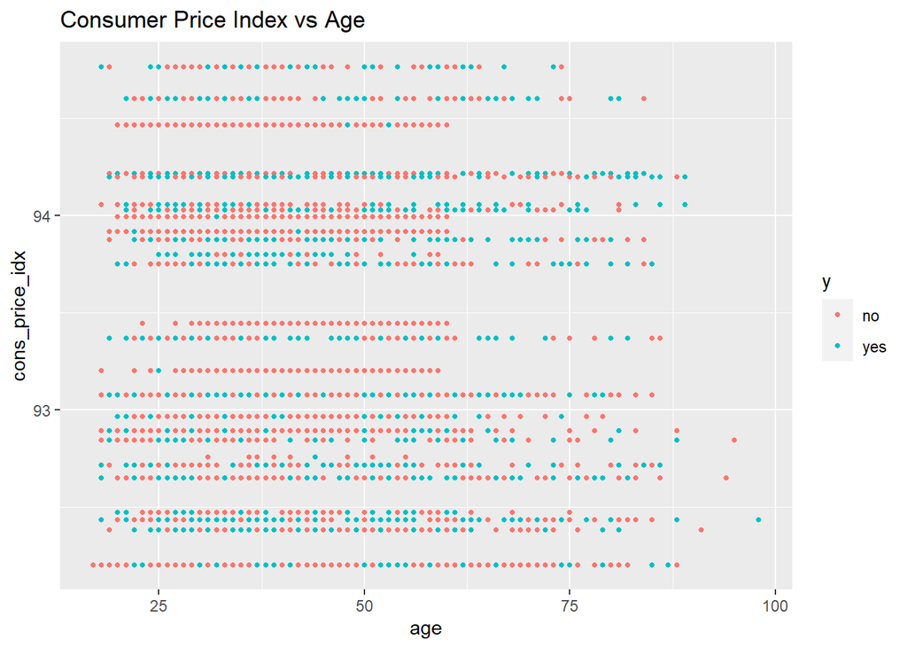

```r
ggplot(df, aes(x = age, y = cons_price_idx, color = y)) +
  geom_point(size = 1, shape = "circle") +
  ggtitle("Consumer Price Index vs Age")
```

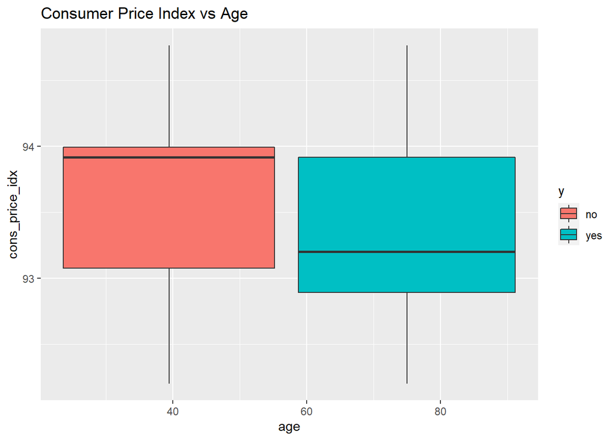

```r
#Checking collinearlity using box plots
ggplot(df, aes(x = age, y = cons_price_idx, fill = y)) +
  geom_boxplot() +
  ggtitle("Consumer Price Index vs Age")
```

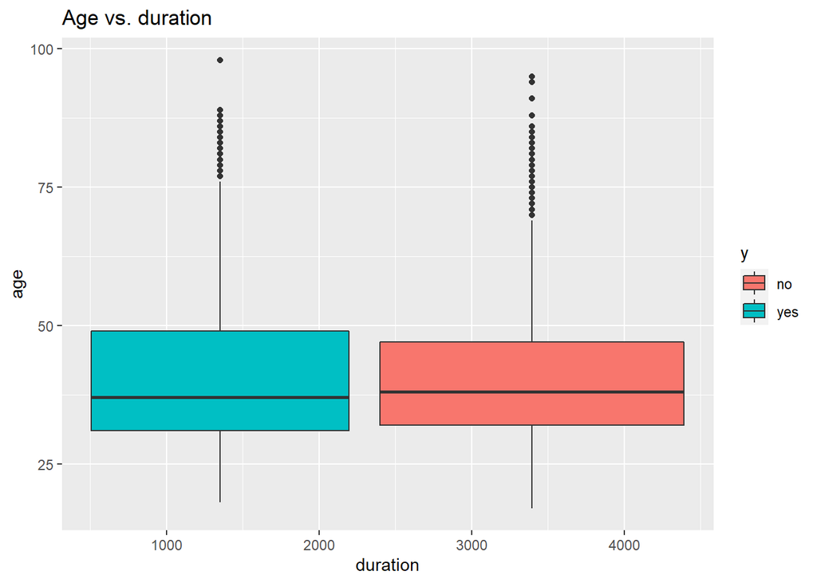

```r
ggplot(df, aes(x = duration , y = age, fill = y)) +
  geom_boxplot() +   ggtitle("Age vs. duration")
```

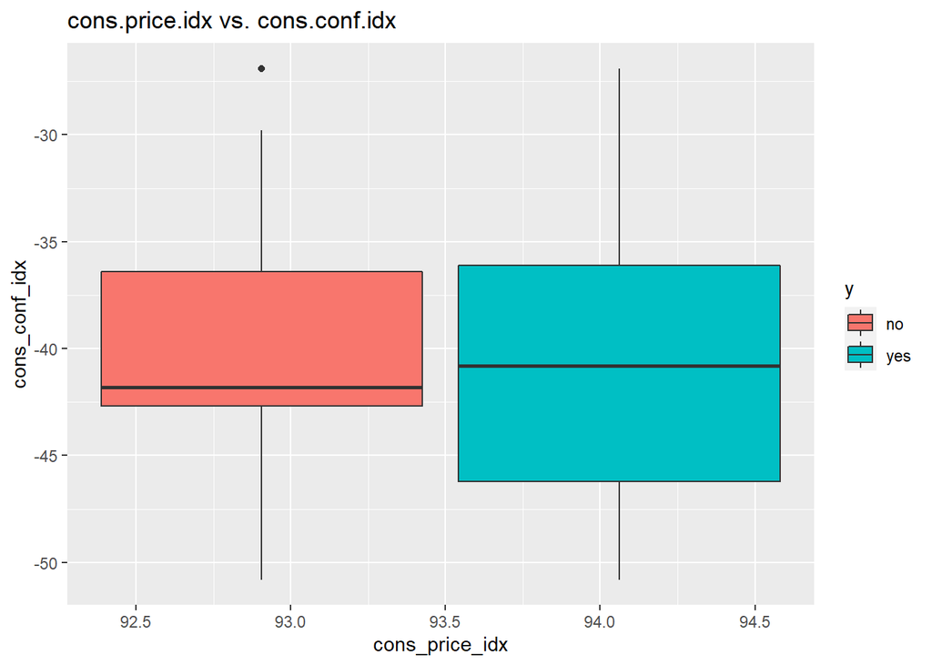

```r
ggplot(df, aes(x = cons_price_idx , y = cons_conf_idx, fill = y)) +
  geom_boxplot() +
  ggtitle("cons.price.idx vs. cons.conf.idx")
```

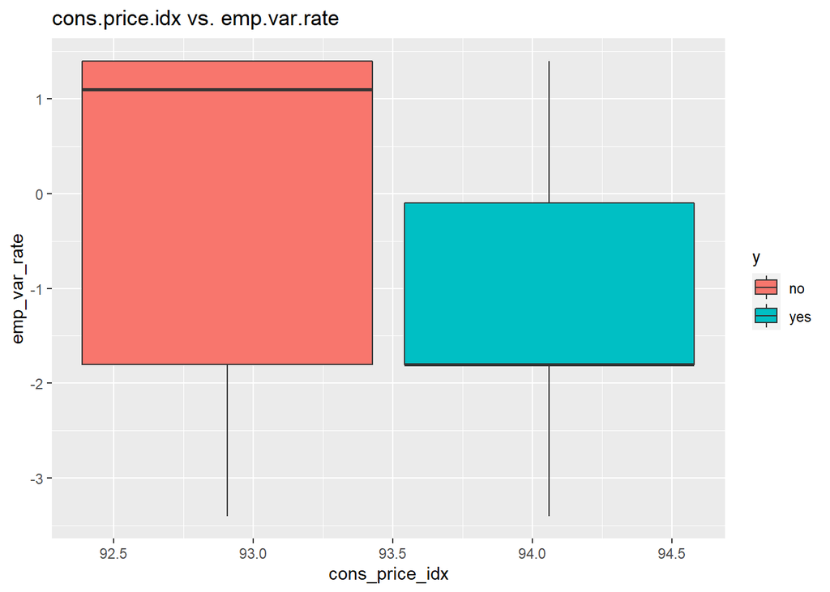

```r
ggplot(df, aes(x = cons_price_idx , y = emp_var_rate, fill = y)) +
  geom_boxplot() +
  ggtitle("cons.price.idx vs. emp.var.rate")
```

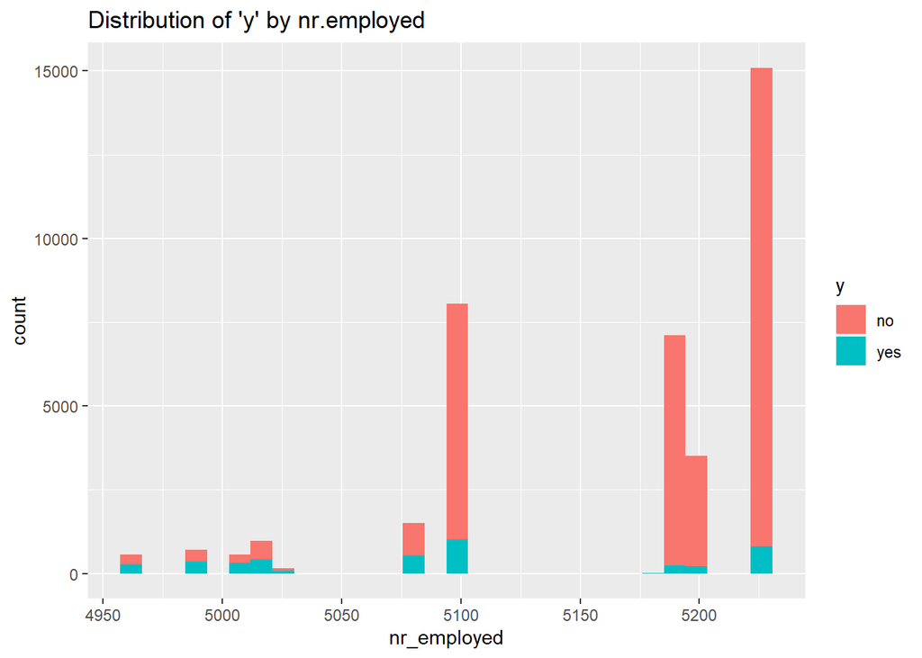

```r
ggplot(df) + geom_histogram(mapping = aes(x = nr_employed, fill = y)) +
  ggtitle("Distribution of 'y' by nr.employed")
```

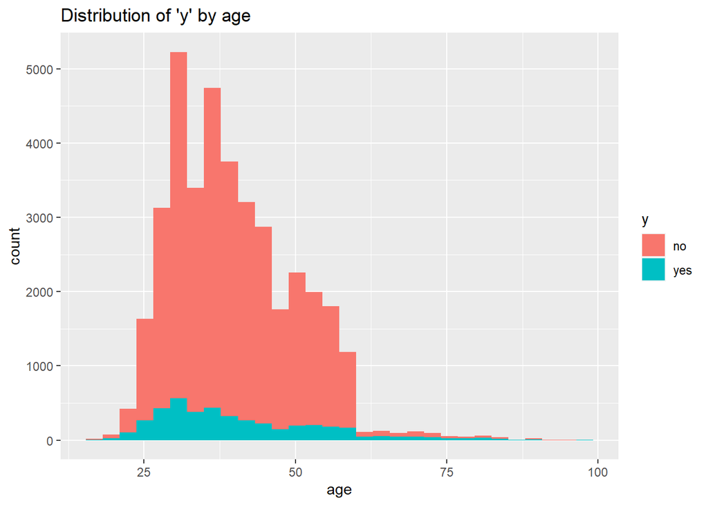

```r
# ggplot(bank_additional_full, aes(x=age, y=education)) +
#   geom_point(size=1, shape="circle") +
#   ggtitle("Education vs Age")  +
#    facet_wrap(~ y)
ggplot(df)+
  geom_histogram(mapping = aes(x = age, fill = y)) +
  ggtitle("Distribution of 'y' by age")
```

## Creating new variables

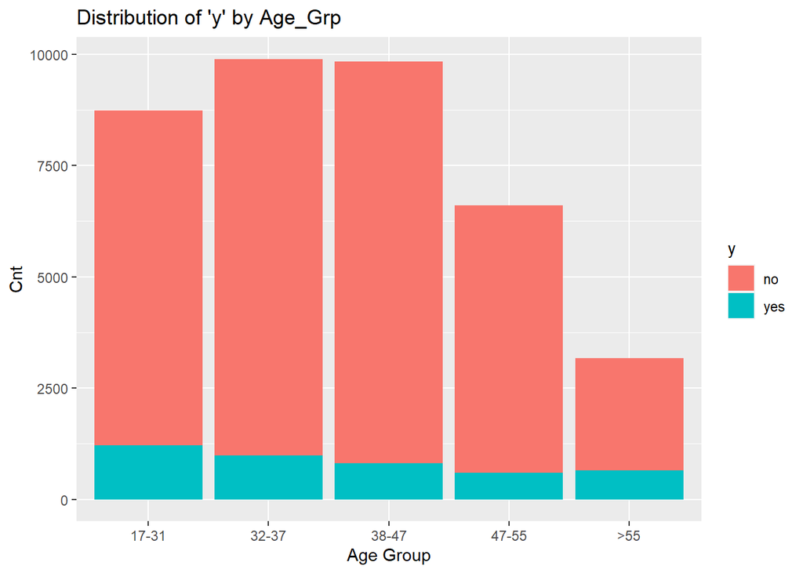

```r
#Age_Grp - split the data into age groups "17-31","32-37" ,"38-47", "47-55", ">55" (based in IQR)
df$Age_Grp <- cut(df$age, breaks = c(16,31,37,46,55,98), labels = c("17-31","32-37" ,"38-47", "47-55", ">55"))

#validate the cut command
#df %>% filter(!$Age_Grp  %in% c("17-31","32-37" ,"38-47", "47-55", ">55"))
#df %>% filter(df$age==55)

ggplot(df) +
  geom_bar(mapping = aes(x=Age_Grp, fill = y)) +
  ggtitle("Distribution of 'y' by Age_Grp") +
  ylab("Cnt") +
  xlab("Age Group")
```

We will keep both age and age group in our model to see if one is selected over the other. We need to make sure to not use both in our model building.

### Analyzing pdays

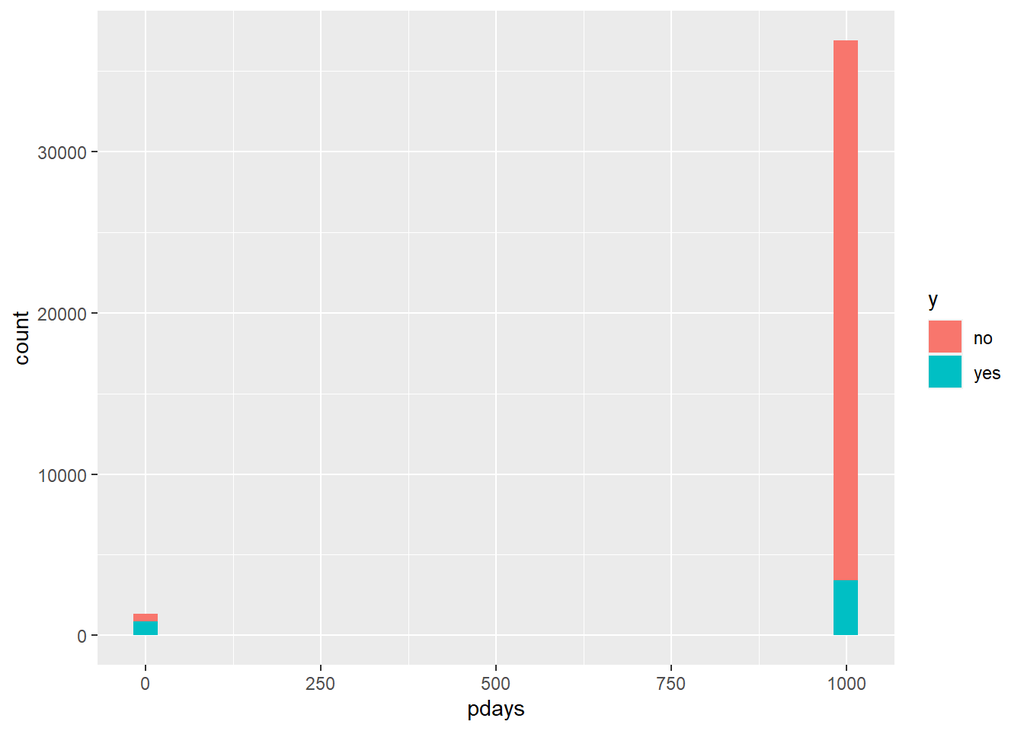

```r
ggplot(df) +
  geom_histogram(mapping = aes(x=pdays, fill=y))
```

Analyzing ‘pdays’ ie., number of days that passed by after the client was last contacted from a previous campaign (numeric; 999 means client was not previously contacted)

Most folks had no previous campaign but if they did, it looks like most who had a previous campaign decided to subscribe

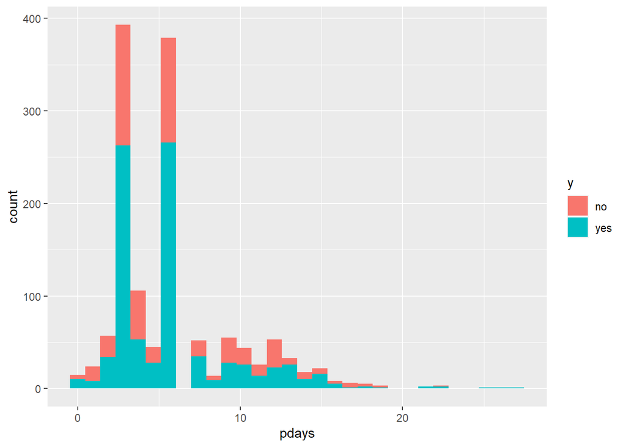

```r
#zoom in for ones that were previously contacted
df %>%
  filter(pdays < 999) %>%
  ggplot() +
  geom_histogram(mapping = aes(x=pdays, fill=y))
```

Highest frequency appears to be less than 10 days since last contact. Let’‘s make this into a y/n variable instead due to the large gap between days contacted and the ’999’ variable.

prevly_Cntctd Yes/No. TO see the distribution or ‘Y’ on first time contact vs. a follow up

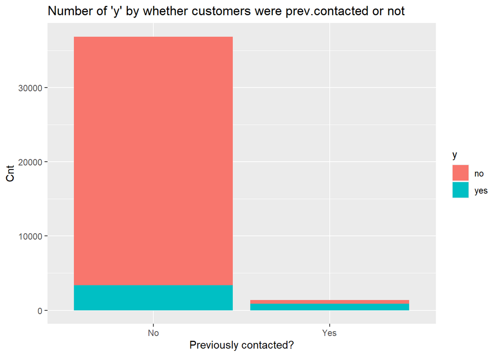

```r
df$prevly_Cntctd <- as.factor(case_when(df$pdays==999 ~ "No", !df$pdays==999 ~ "Yes"))

#Validate previously contacted variable

#df %>% filter(!df$pdays==999)

ggplot(df) +
  geom_bar(mapping = aes(x=prevly_Cntctd, fill = y)) +
  ggtitle("Number of 'y' by whether customers were prev.contacted or not") +
  ylab("Cnt") +
  xlab("Previously contacted?")
```

Same observation here as above: Most folks had no previous campaign but if they did, it looks like most who had a previous campaign decided to subscribe / likely to say ‘Yes’.

### Analysing campaign

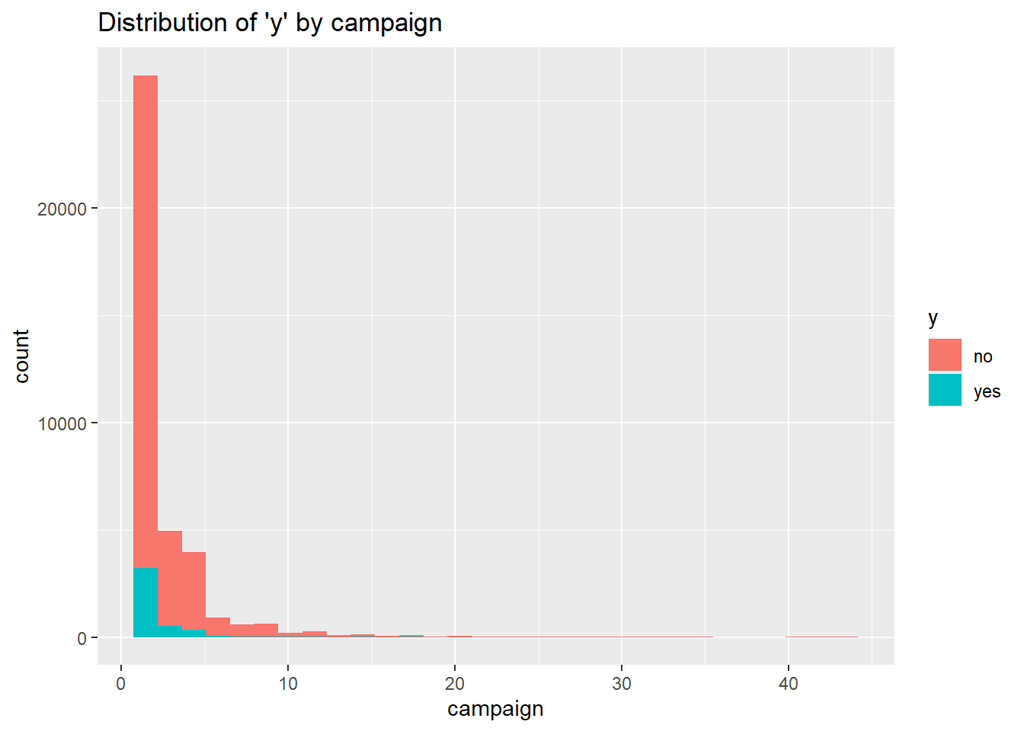

```r
ggplot(df) +
  geom_histogram(mapping = aes(x=campaign, fill=y)) +
  ggtitle("Distribution of 'y' by campaign")
```

Just visually, when we decided to stop contacting a person it didn’t affect our closing ratio which still dropped off precipitously

Ideally, the campaign would stop contacting people who are less likely to subscribe, and keep contacting people if they are more likely to subscribe. Then we should see the ratio of Yes to No go up as the number of no contacts goes up. Instead, it looks like the ratio stays the same and the number of Yes’’s drops proportionately with the number of No’s.

### Analyzing job

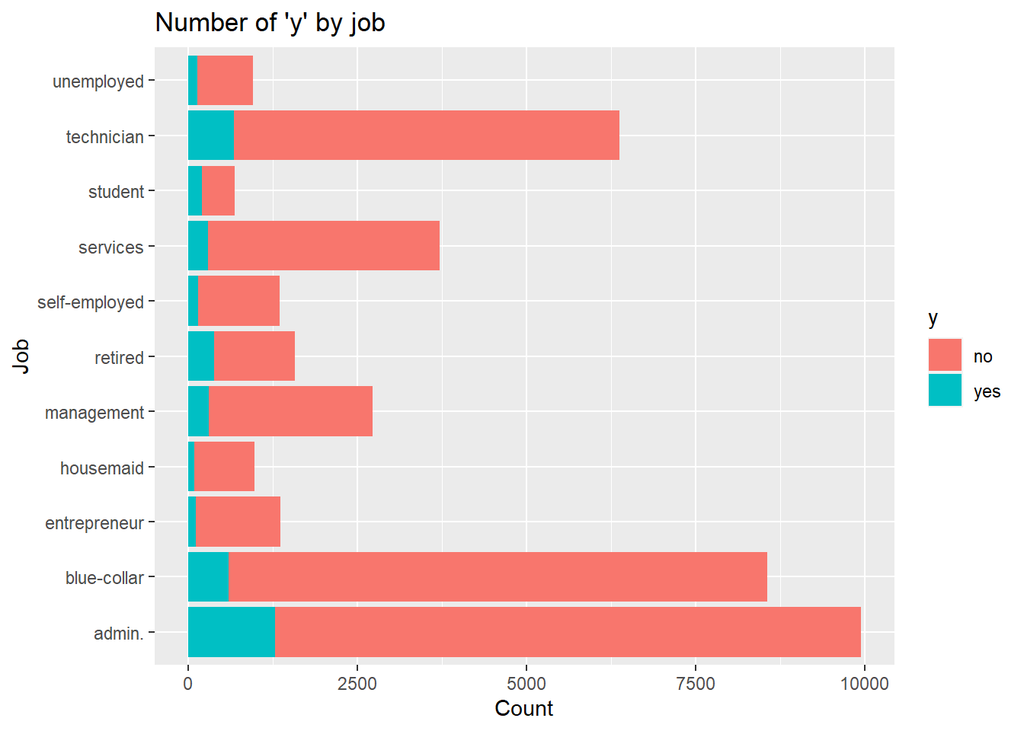

```r
ggplot(df) +
  geom_bar(mapping = aes(x=job, fill = y)) +
  coord_flip() +     #Added coord flip here to make it more readable
  ggtitle("Number of 'y' by job") +
  ylab("Count") +
  xlab("Job")
```

“y” - has a client subscribed a term deposit? : admin, technician and blue collar jobs are the top 3 subscribers by volume

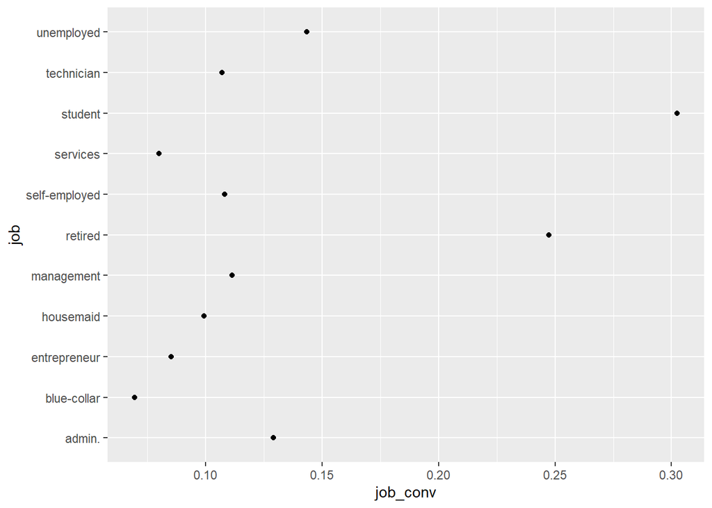

```r
df2 <- df %>%
  group_by(job) %>%
  count(y) %>%
  mutate(job_conv = n/sum(n)) %>%
  filter(y == "yes")

ggplot(df2, aes(x=job, y=job_conv)) +
  geom_point() +
  coord_flip()
```

Above, I looked at the ratio of “yes” vs “no” and see that students and retired persons convert at much higher rates than those of other professions. And ‘blue collar’ has the lowest conversion rate

So, if they were to want to improve the cost effectiveness of their campaigns they might want to target more ‘students’ and ‘retirees’

### Analyzing marital

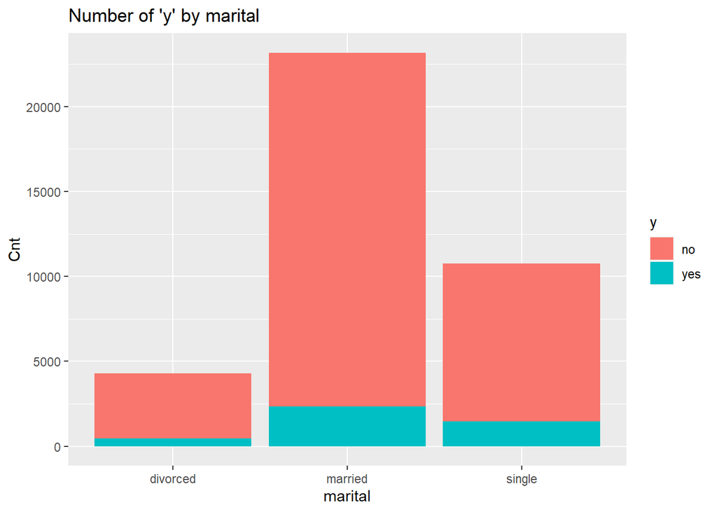

```r
ggplot(data = df) +
  geom_bar(mapping = aes(x = marital, fill = y)) +
  ggtitle("Number of 'y' by marital") +
  ylab("Cnt") +
  xlab("marital")
```

More ‘married’ people are represented in the campaign Visually looking, conversion rate seems to be higher for ‘single’ people

### Analyzing duration and creating duration group variable

```r
summary(df$duration)
```

```
##    Min. 1st Qu.  Median    Mean 3rd Qu.    Max.
##     0.0   102.0   180.0   258.2   319.0  4918.0
```

```r
df$duration_group <-cut(df$duration,breaks = c(-Inf,300,600,Inf),labels = c("0-5min", "5-10min","10+ min"))

# Check for missing values
tibble(variable = names(colSums(is.na(df))),
       missing = colSums(is.na(df))) %>%
  gt() %>%
  tab_header(title = "Missing Values in Data")
```

Missing Values in Data

| variable | missing |
| --- | --- |
| age | 0 |
| job | 0 |
| marital | 0 |
| education | 0 |
| default | 0 |
| housing | 0 |
| loan | 0 |
| contact | 0 |
| month | 0 |
| day_of_week | 0 |
| duration | 0 |
| campaign | 0 |
| pdays | 0 |
| previous | 0 |
| poutcome | 0 |
| emp_var_rate | 0 |
| cons_price_idx | 0 |
| cons_conf_idx | 0 |
| euribor3m | 0 |
| nr_employed | 0 |
| y | 0 |
| Age_Grp | 0 |
| prevly_Cntctd | 0 |
| duration_group | 0 |

```r
df3 <- df %>%
  group_by(duration_group) %>%
  count(y) %>%
  mutate(duration_group_conv = n/sum(n)) %>%
  filter(y == "yes")

df3
```

```
## # A tibble: 3 x 4
## # Groups:   duration_group [3]
##   duration_group y         n duration_group_conv
##   <fct>          <fct> <int>               <dbl>
## 1 0-5min         yes    1375              0.0494
## 2 5-10min        yes    1323              0.184
## 3 10+ min        yes    1560              0.486
```

```r
#ggplot(df3, aes(x=duration_group, y=duration_group_conv)) +  geom_point() +  facet_wrap(~ y)
```

Looking above, clearly conversion rate goes up the longer the most recent call

### Visualizing categorical variables

```r
prop.table(table(df$prevly_Cntctd,df$duration_group),2)
```

```
##
##           0-5min    5-10min    10+ min
##   No  0.96993858 0.94741967 0.95295950
##   Yes 0.03006142 0.05258033 0.04704050
```

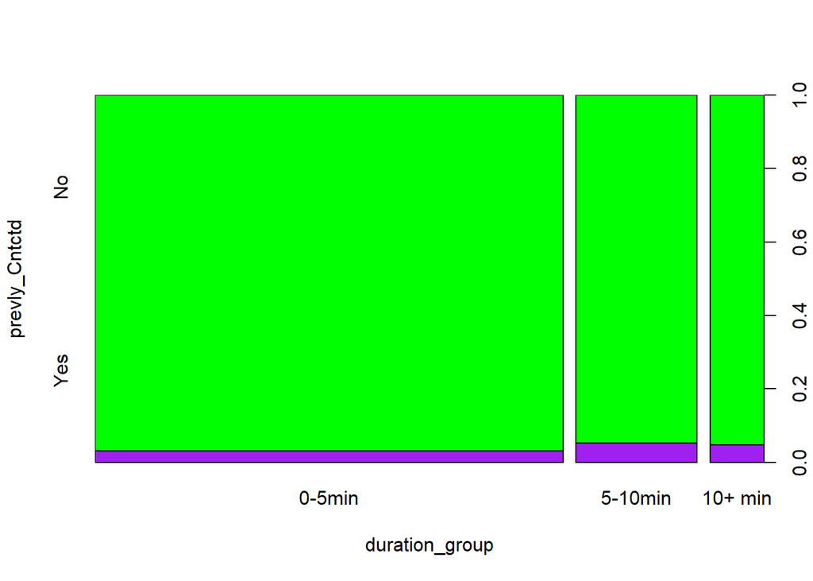

```r
plot(prevly_Cntctd~duration_group,data=df,col=c("purple","green"))
```

```r
prop.table(table(df$prevly_Cntctd,df$y),2)
```

```
##
##               no        yes
##   No  0.98525777 0.79685298
##   Yes 0.01474223 0.20314702
```

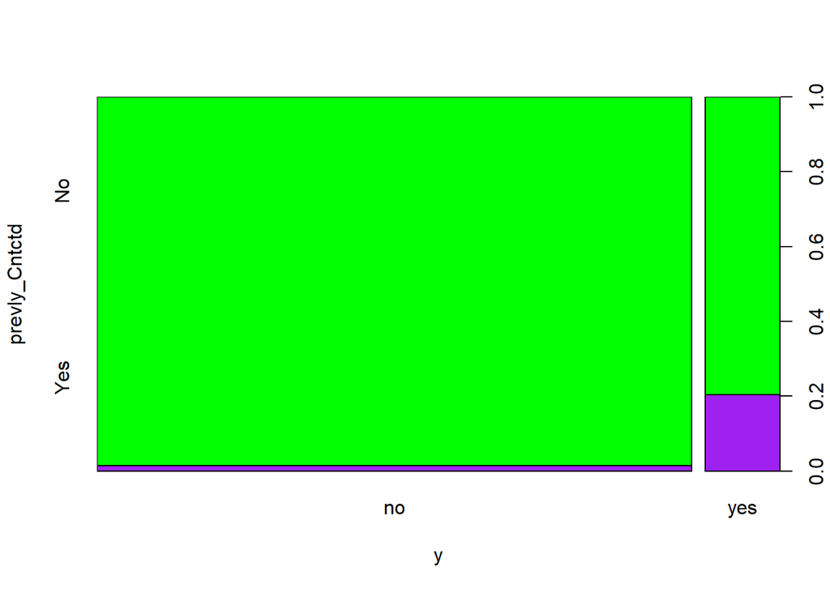

```r
plot(prevly_Cntctd~y,data=df,col=c("purple","green"))
```

```r
prop.table(table(df$education,df$marital),2)
```

```
##
##                           divorced      married       single
##   basic.4y            0.1113435611 0.1334771355 0.0398698885
##   basic.6y            0.0404463040 0.0738567731 0.0295539033
##   basic.9y            0.1276150628 0.1742450388 0.1178438662
##   high.school         0.2701069270 0.2164365833 0.2847583643
##   illiterate          0.0004649000 0.0006471096 0.0000929368
##   professional.course 0.1480706648 0.1327868852 0.1285315985
##   university.degree   0.3019525802 0.2685504745 0.3993494424
```

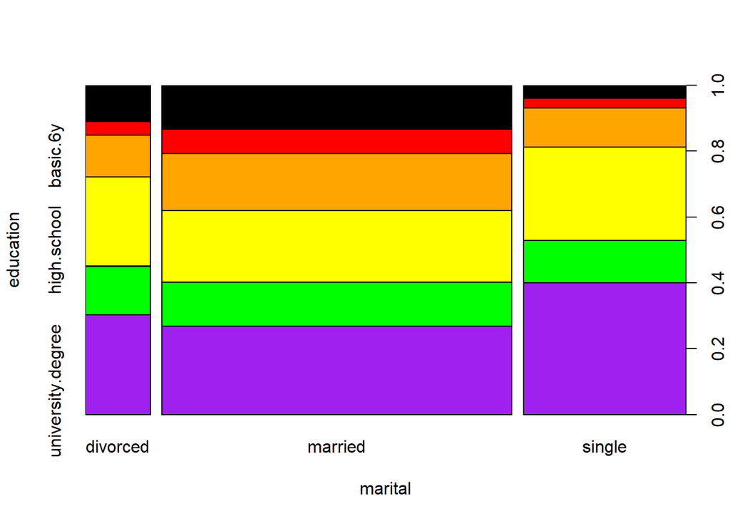

```r
plot(education~marital,data=df,col=c("purple","green","blue","yellow","orange","red","black"))
```

```r
prop.table(table(df$duration_group,df$y),2)
```

```
##
##                   no        yes
##   0-5min  0.77883710 0.32292156
##   5-10min 0.17261064 0.31070925
##   10+ min 0.04855226 0.36636919
```

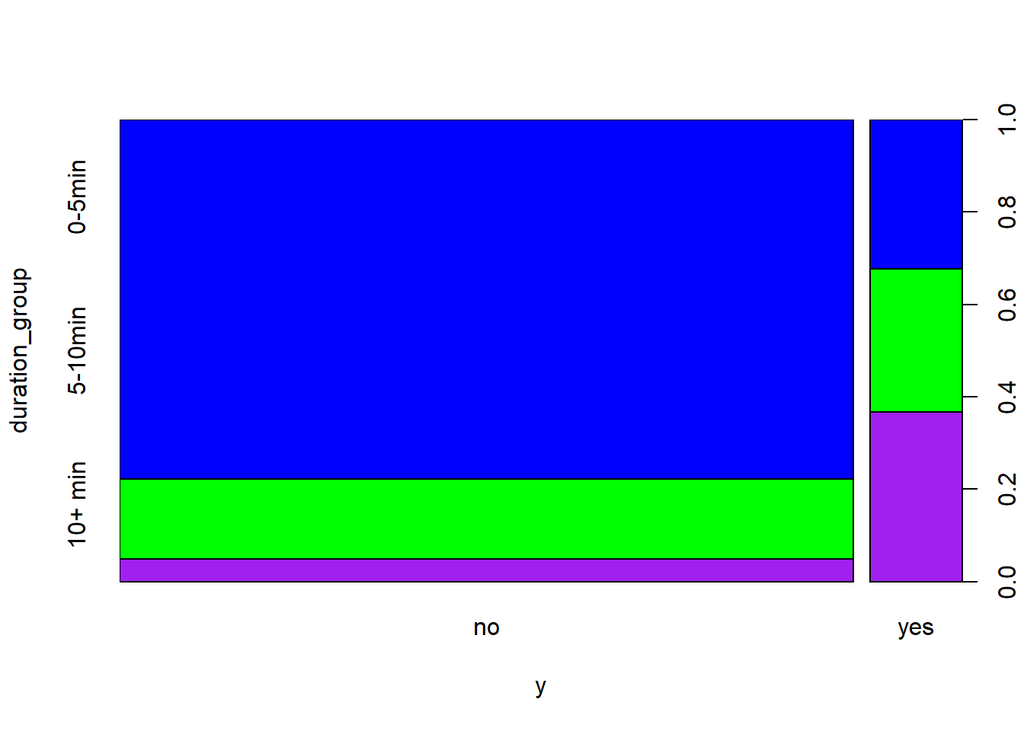

```r
plot(duration_group~y,data=df,col=c("purple","green","blue"))
```

Checking proportions for duration groups and response var

```r
prop.table(table(df$y,df$duration_group),2)
```

```
##
##           0-5min    5-10min    10+ min
##   no  0.95061595 0.81596884 0.51401869
##   yes 0.04938405 0.18403116 0.48598131
```

Check conversion rates by education levels

```r
df %>%
  group_by(education) %>%
  count(y) %>%
  mutate(education_conv = n/sum(n)) %>%
  filter(y == "yes")
```

```
## # A tibble: 7 x 4
## # Groups:   education [7]
##   education           y         n education_conv
##   <fct>               <fct> <int>          <dbl>
## 1 basic.4y            yes     412         0.103
## 2 basic.6y            yes     180         0.0817
## 3 basic.9y            yes     457         0.0780
## 4 high.school         yes    1007         0.109
## 5 illiterate          yes       4         0.222
## 6 professional.course yes     578         0.113
## 7 university.degree   yes    1620         0.137
```

```r
df %>%
  group_by(education) %>%
  count(y) %>%
  mutate(education_conv = n/sum(n)) %>%
  filter(y == "yes")
```

```
## # A tibble: 7 x 4
## # Groups:   education [7]
##   education           y         n education_conv
##   <fct>               <fct> <int>          <dbl>
## 1 basic.4y            yes     412         0.103
## 2 basic.6y            yes     180         0.0817
## 3 basic.9y            yes     457         0.0780
## 4 high.school         yes    1007         0.109
## 5 illiterate          yes       4         0.222
## 6 professional.course yes     578         0.113
## 7 university.degree   yes    1620         0.137
```